# Team5_FinalProject_Code

```python
import pandas as pd
import numpy as np
import re
import unicodedata
import matplotlib.pyplot as plt
import seaborn as sns
import pandas as pd
from sklearn.preprocessing import StandardScaler, OneHotEncoder, FunctionTransformer
from sklearn.compose import ColumnTransformer
import numpy as np
import pandas as pd
from sklearn.ensemble import RandomForestClassifier
```

1. Importing the dataset
2. Data Pre-processing
3. Feature Engineering and EDA
4. NLP for the text columns
5. Data Splitting
6. Deep Learning
7. PCA and imbalance correction

# Importing the dataset

```python
df = pd.read_csv("dataset (1).csv")
```

```python
len(df)
```

```
114000
```

# Data Pre-processing

```python
# Removing the unnamed column 'Unnamed: 0'
df.drop(columns=['Unnamed: 0'], inplace=True)
```

```python
missing_values = df.isnull().sum()
print(missing_values)
```

```
track_id            0
artists             1
album_name          1
track_name          1
popularity          0
duration_ms         0
explicit            0
danceability        0
energy              0
key                 0
loudness            0
mode                0
speechiness         0
acousticness        0
instrumentalness    0
liveness            0
valence             0
tempo               0
time_signature      0
track_genre         0
dtype: int64
```

```python
df.dropna(subset=['artists', 'album_name', 'track_name'], inplace=True)
```

### Checking for Non-Ascii and Removing them

```python
# Define a function to check if a string contains non-ASCII characters
def contains_non_ascii(string):
    return any(char not in set(chr(i) for i in range(128)) for char in string)

# Get rows with non-ASCII characters in 'artists' column
non_ascii_artists = df[df['artists'].apply(contains_non_ascii)]
print("Rows to be removed from 'artists' column:")
print(non_ascii_artists['artists'].sample(5))

# Get rows with non-ASCII characters in 'album_name' column
non_ascii_albums = df[df['album_name'].apply(contains_non_ascii)]
print("\nRows to be removed from 'album_name' column:")
print(non_ascii_albums['album_name'].sample(5))

# Get rows with non-ASCII characters in 'track_name' column
non_ascii_tracks = df[df['track_name'].apply(contains_non_ascii)]
print("\nRows to be removed from 'track_name' column:")
print(non_ascii_tracks['track_name'].sample(5))

confirmation = 'y'

if confirmation.lower() == 'y':
    # Remove rows with non-ASCII characters in 'artists' column
    df = df[~df['artists'].apply(contains_non_ascii)]

    # Remove rows with non-ASCII characters in 'album_name' column
    df = df[~df['album_name'].apply(contains_non_ascii)]

    # Remove rows with non-ASCII characters in 'track_name' column
    df = df[~df['track_name'].apply(contains_non_ascii)]

    print("Rows containing non-ASCII values have been removed.")
else:
    print("No changes made to the dataset.")
```

```
Rows to be removed from 'artists' column:
6716                                       Truchło Strzygi
58701                                             Ill Niño
77670                                         Di Propósito
8307                                            Zayde Wølf
76241    Alfredo Catalani;Cristina Gallardo-Domas;Mauri...
Name: artists, dtype: object

Rows to be removed from 'album_name' column:
108767    Antihéroes y Tumbas (Historias del Gótico Surero)
61123                           E 〜Complete A side Singles〜
65864                              Love Yourself 結 'Answer'
61473                           E 〜Complete A side Singles〜
93050                   Легенды всех времен - Игорь Тальков
Name: album_name, dtype: object

Rows to be removed from 'track_name' column:
88160                                             GATÚBELA
14342                   Teté (Metete teté) - Remasterizado
97346    Pout Pourri - por Te Amar Assim / Coração Band...
9445                                     Tua Presença Cura
63570                                              リバーシブルー
Name: track_name, dtype: object
Rows containing non-ASCII values have been removed.
```

There are a lot of non english words and names that are causing issues with the data and are hindering the analysis. To mitigate that, I am using the ASCII representation to recognize everything that is not ascii. As we can see, removing those also doesn't hamper the size of the dataset as much as we would expect thus helping further with the analysis.

```python
len(df)
```

```
88725
```

```python
df.to_csv("non-ascii.csv")
```

### From the above non-ascii cleaned dataset, removing all the different instances of the null values.

```python
df = pd.read_csv("non-ascii.csv")
```

```python
# Check for missing values
df.drop(columns=['Unnamed: 0'], inplace=True)

missing_values = df.isnull().sum()
missing_values
```

```
track_id            0
artists             0
album_name          0
track_name          0
popularity          0
duration_ms         0
explicit            0
danceability        0
energy              0
key                 0
loudness            0
mode                0
speechiness         0
acousticness        0
instrumentalness    0
liveness            0
valence             0
tempo               0
time_signature      0
track_genre         0
dtype: int64
```

```python
# List of strings to consider as NaN
null_values = ['', 'None', 'nan', 'null']

df.replace(null_values, np.nan, inplace=True)

missing_values_updated = df.isnull().sum()
missing_values_updated
```

```
track_id            0
artists             0
album_name          0
track_name          0
popularity          0
duration_ms         0
explicit            0
danceability        0
energy              0
key                 0
loudness            0
mode                0
speechiness         0
acousticness        0
instrumentalness    0
liveness            0
valence             0
tempo               0
time_signature      0
track_genre         0
dtype: int64
```

```python
df.shape
```

```
(88725, 20)
```

```python
# Check to see how many duplicate rows we have
number_of_duplicates = df.duplicated().sum()
print(f"Number of duplicate rows: {number_of_duplicates}")

# Remove duplicate rows
df.drop_duplicates(inplace=True)

df_shape_after_duplicates_removed = df.shape
print(f"Shape of DataFrame after removing duplicates: {df_shape_after_duplicates_removed}")
```

```
Number of duplicate rows: 317
Shape of DataFrame after removing duplicates: (88408, 20)
```

```python
# Check the current data types of all columns
df.dtypes
```

```
track_id             object
artists              object
album_name           object
track_name           object
popularity            int64
duration_ms           int64
explicit               bool
danceability        float64
energy              float64
key                   int64
loudness            float64
mode                  int64
speechiness         float64
acousticness        float64
instrumentalness    float64
liveness            float64
valence             float64
tempo               float64
time_signature        int64
track_genre          object
dtype: object
```

```python
# Convert 'track_genre' to 'category' datatype
df['track_genre'] = df['track_genre'].astype('category')

# Verify the change
df.dtypes
```

```
track_id              object
artists               object
album_name            object
track_name            object
popularity             int64
duration_ms            int64
explicit                bool
danceability         float64
energy               float64
key                    int64
loudness             float64
mode                   int64
speechiness          float64
acousticness         float64
instrumentalness     float64
liveness             float64
valence              float64
tempo                float64
time_signature         int64
track_genre         category
dtype: object
```

```python
df.to_csv("cleaned_df.csv",index=False)
```

# Feature Engineering and EDA

```python
df = pd.read_csv("cleaned_df.csv")
```

```python
df.head()
```

|  | track_id | artists | album_name | track_name | popularity | duration_ms | explicit | danceability | energy | key | loudness | mode | speechiness | acousticness | instrumentalness | liveness | valence | tempo | time_signature | track_genre |
| --- | --- | --- | --- | --- | --- | --- | --- | --- | --- | --- | --- | --- | --- | --- | --- | --- | --- | --- | --- | --- |
| 0 | 5SuOikwiRyPMVoIQDJUgSV | Gen Hoshino | Comedy | Comedy | 73 | 230666 | False | 0.676 | 0.4610 | 1 | -6.746 | 0 | 0.1430 | 0.0322 | 0.000001 | 0.3580 | 0.715 | 87.917 | 4 | acoustic |
| 1 | 4qPNDBW1i3p13qLCt0Ki3A | Ben Woodward | Ghost (Acoustic) | Ghost - Acoustic | 55 | 149610 | False | 0.420 | 0.1660 | 1 | -17.235 | 1 | 0.0763 | 0.9240 | 0.000006 | 0.1010 | 0.267 | 77.489 | 4 | acoustic |
| 2 | 1iJBSr7s7jYXzM8EGcbK5b | Ingrid Michaelson;ZAYN | To Begin Again | To Begin Again | 57 | 210826 | False | 0.438 | 0.3590 | 0 | -9.734 | 1 | 0.0557 | 0.2100 | 0.000000 | 0.1170 | 0.120 | 76.332 | 4 | acoustic |
| 3 | 6lfxq3CG4xtTiEg7opyCyx | Kina Grannis | Crazy Rich Asians (Original Motion Picture Sou... | Can't Help Falling In Love | 71 | 201933 | False | 0.266 | 0.0596 | 0 | -18.515 | 1 | 0.0363 | 0.9050 | 0.000071 | 0.1320 | 0.143 | 181.740 | 3 | acoustic |
| 4 | 5vjLSffimiIP26QG5WcN2K | Chord Overstreet | Hold On | Hold On | 82 | 198853 | False | 0.618 | 0.4430 | 2 | -9.681 | 1 | 0.0526 | 0.4690 | 0.000000 | 0.0829 | 0.167 | 119.949 | 4 | acoustic |

### Dealing with the Artists column

```python
# creating an artist count column which indicates the number of artists for each song
df['artist_count'] = df['artists'].apply(lambda x: len(x.split(';')))
print(df[['artists', 'artist_count']].head())
```

```
                  artists  artist_count
0             Gen Hoshino             1
1            Ben Woodward             1
2  Ingrid Michaelson;ZAYN             2
3            Kina Grannis             1
4        Chord Overstreet             1
```

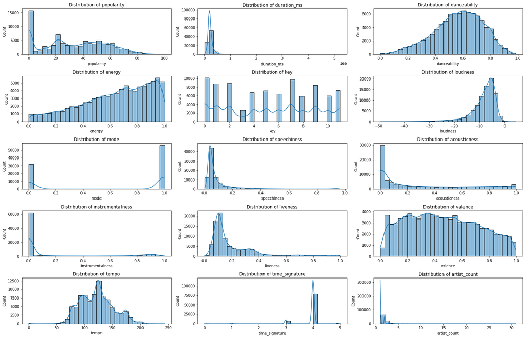

```python
# Select only numerical features for visualization
numerical_features = df.select_dtypes(include=['int64', 'float64']).columns

# Create a histogram for each numerical feature
plt.figure(figsize=(20, 15))
for i, feature in enumerate(numerical_features):
    plt.subplot(len(numerical_features) // 3 + 1, 3, i + 1)
    sns.histplot(df[feature], bins=30, kde=True)
    plt.title(f'Distribution of {feature}')
plt.tight_layout()
plt.show()
```

```python
#data = df

log_transform_cols = ['duration_ms', 'tempo', 'artist_count']
standardize_cols = ['loudness']
one_hot_encode_cols = ['key', 'time_signature']

# Define the transformers
log_transformer = FunctionTransformer(np.log1p, validate=False)
standardizer = StandardScaler()
one_hot_encoder = OneHotEncoder()

# Create the preprocessing pipeline
preprocessor = ColumnTransformer(
    transformers=[
        ('log', log_transformer, log_transform_cols),
        ('std', standardizer, standardize_cols),
        ('onehot', one_hot_encoder, one_hot_encode_cols)
    ],
    remainder='passthrough' # Passthrough columns not specified in transformers
)

# Apply the preprocessing pipeline to the dataset
data_transformed = preprocessor.fit_transform(df)

# Retrieve feature names for one-hot encoded columns
one_hot_features = preprocessor.named_transformers_['onehot'].get_feature_names_out(one_hot_encode_cols)
transformed_columns = (log_transform_cols + standardize_cols + list(one_hot_features))

# Other columns that were not transformed
remainder_cols = [col for col in df.columns if col not in (log_transform_cols + standardize_cols + one_hot_encode_cols)]

# Combine all column names
all_columns = transformed_columns + remainder_cols

# Convert the transformed data back to a DataFrame
data_preprocessed = pd.DataFrame(data_transformed, columns=all_columns)

# Show the head of the preprocessed DataFrame
print(data_preprocessed.head())
```

```
  duration_ms     tempo artist_count  loudness key_0 key_1 key_2 key_3 key_4  \
0    12.34873  4.487703     0.693147  0.309687   0.0   1.0   0.0   0.0   0.0
1   11.915794  4.362958     0.693147 -1.765712   0.0   1.0   0.0   0.0   0.0
2   12.258793  4.348108     1.098612 -0.281532   1.0   0.0   0.0   0.0   0.0
3   12.215696  5.208064     0.693147 -2.018979   1.0   0.0   0.0   0.0   0.0
4   12.200326  4.795369     0.693147 -0.271045   0.0   0.0   1.0   0.0   0.0

  key_5  ... explicit danceability  energy mode speechiness acousticness  \
0   0.0  ...    False        0.676   0.461    0       0.143       0.0322
1   0.0  ...    False         0.42   0.166    1      0.0763        0.924
2   0.0  ...    False        0.438   0.359    1      0.0557         0.21
3   0.0  ...    False        0.266  0.0596    1      0.0363        0.905
4   0.0  ...    False        0.618   0.443    1      0.0526        0.469

  instrumentalness liveness valence track_genre
0         0.000001    0.358   0.715    acoustic
1         0.000006    0.101   0.267    acoustic
2              0.0    0.117    0.12    acoustic
3         0.000071    0.132   0.143    acoustic
4              0.0   0.0829   0.167    acoustic

[5 rows x 36 columns]
```

```python
data_preprocessed.columns
```

```
Index(['duration_ms', 'tempo', 'artist_count', 'loudness', 'key_0', 'key_1',
       'key_2', 'key_3', 'key_4', 'key_5', 'key_6', 'key_7', 'key_8', 'key_9',
       'key_10', 'key_11', 'time_signature_0', 'time_signature_1',
       'time_signature_3', 'time_signature_4', 'time_signature_5', 'track_id',
       'artists', 'album_name', 'track_name', 'popularity', 'explicit',
       'danceability', 'energy', 'mode', 'speechiness', 'acousticness',
       'instrumentalness', 'liveness', 'valence', 'track_genre'],
      dtype='object')
```

```python
#data_preprocessed.to_csv("data_preprocessed.csv", index = False)
```

```python
data_preprocessed.dtypes
```

```
duration_ms         object
tempo               object
artist_count        object
loudness            object
key_0               object
key_1               object
key_2               object
key_3               object
key_4               object
key_5               object
key_6               object
key_7               object
key_8               object
key_9               object
key_10              object
key_11              object
time_signature_0    object
time_signature_1    object
time_signature_3    object
time_signature_4    object
time_signature_5    object
track_id            object
artists             object
album_name          object
track_name          object
popularity          object
explicit            object
danceability        object
energy              object
mode                object
speechiness         object
acousticness        object
instrumentalness    object
liveness            object
valence             object
track_genre         object
dtype: object
```

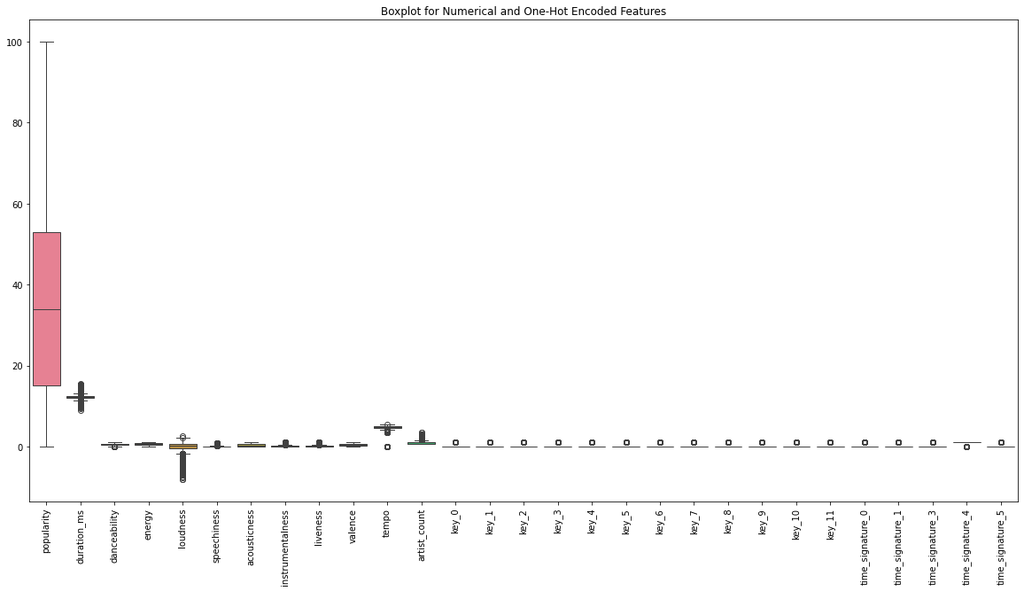

```python
# Original numeric features
numeric_features = [
    'popularity', 'duration_ms', 'danceability', 'energy',
    'loudness', 'speechiness', 'acousticness', 'instrumentalness',
    'liveness', 'valence', 'tempo','artist_count'
]

# Convert the originally numeric features back to their numeric types
for col in numeric_features:
    data_preprocessed[col] = pd.to_numeric(data_preprocessed[col], errors='coerce')

# Convert the one-hot encoded key and time_signature features back to int
key_features = [col for col in data_preprocessed.columns if col.startswith('key_')]
time_signature_features = [col for col in data_preprocessed.columns if col.startswith('time_signature_')]

for col in key_features + time_signature_features:
    data_preprocessed[col] = data_preprocessed[col].astype(int)

# Ensure 'explicit' remains boolean
data_preprocessed['explicit'] = data_preprocessed['explicit'].astype(bool)

# Ensure 'track_genre' remains categorical
data_preprocessed['track_genre'] = data_preprocessed['track_genre'].astype('category')

# Drop rows with NaN values that resulted from the conversion issues
data_preprocessed.dropna(subset=numeric_features, inplace=True)

# Combine all numeric and one-hot encoded features for visualization
all_features_for_visualization = numeric_features + key_features + time_signature_features

# Create boxplots for each numerical feature
plt.figure(figsize=(20, 10))
sns.boxplot(data=data_preprocessed[all_features_for_visualization])
plt.xticks(rotation=90)
plt.title('Boxplot for Numerical and One-Hot Encoded Features')
plt.show()
```

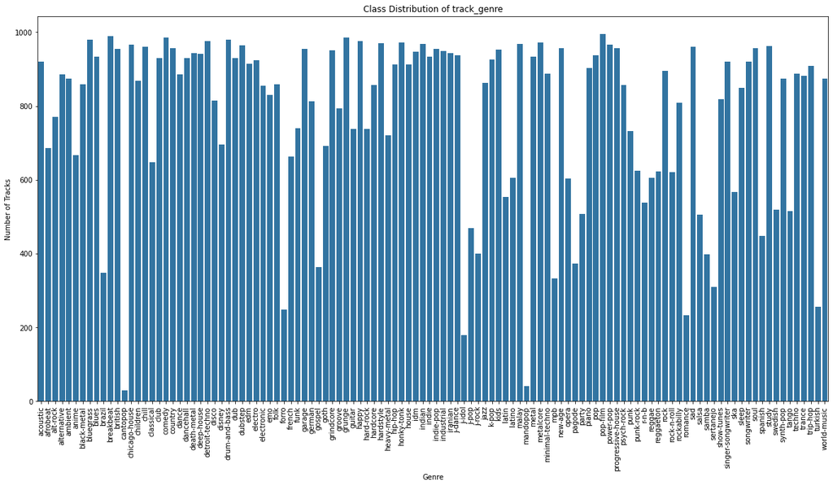

```python
class_counts = data_preprocessed['track_genre'].value_counts()

plt.figure(figsize=(20, 10))
sns.barplot(x=class_counts.index, y=class_counts.values)
plt.title('Class Distribution of track_genre')
plt.xlabel('Genre')
plt.ylabel('Number of Tracks')
plt.xticks(rotation=90)
plt.show()
```

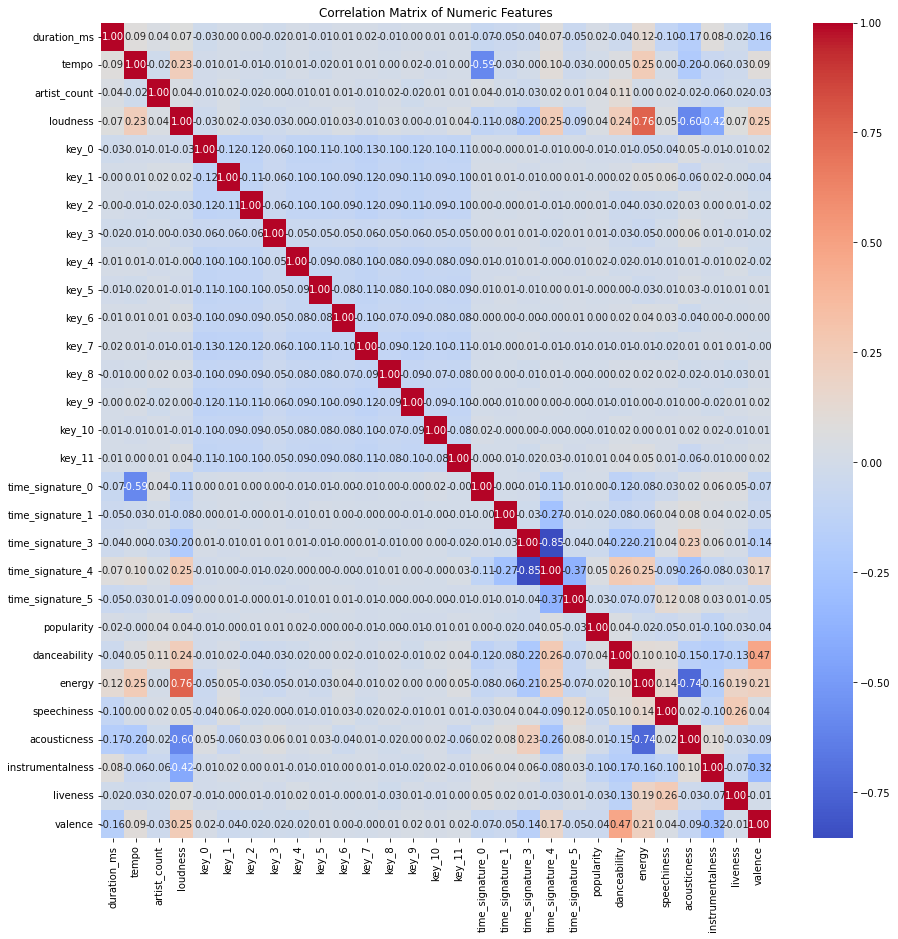

```python
#data = data_preprocessed

# Select only the numeric features for correlation analysis
numeric_features = data_preprocessed.select_dtypes(include=['int64', 'float64']).columns

# Calculate the correlation matrix
corr_matrix = data_preprocessed[numeric_features].corr()

# Plot the heatmap for the correlation matrix
plt.figure(figsize=(15, 15))
sns.heatmap(corr_matrix, annot=True, fmt=".2f", cmap='coolwarm')
plt.title('Correlation Matrix of Numeric Features')
plt.show()
```

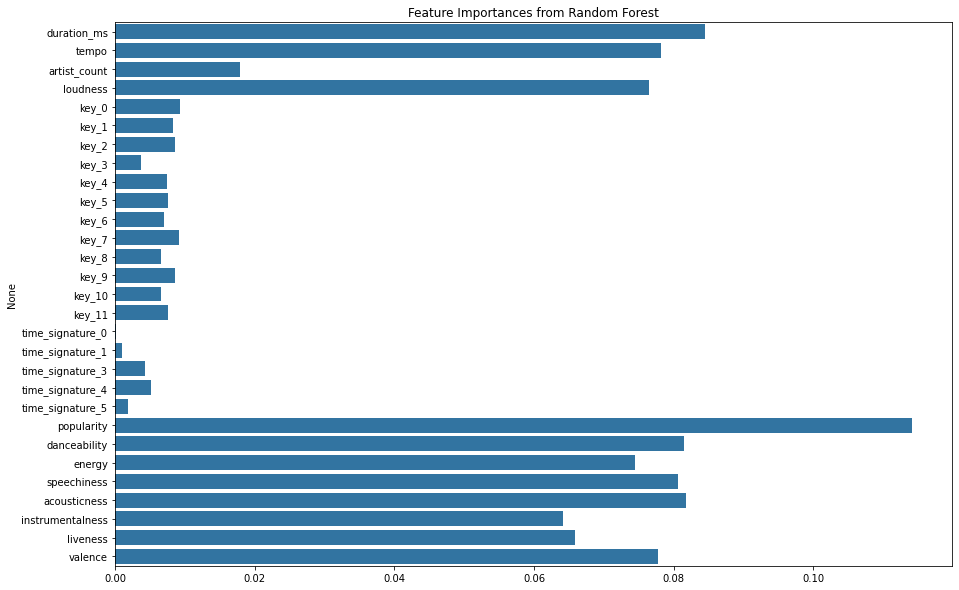

```python
X = data_preprocessed[numeric_features]
y = data_preprocessed['track_genre'].cat.codes

# Initialize the RandomForestClassifier
rf = RandomForestClassifier(n_estimators=100, random_state=42)

# Fit the model
rf.fit(X, y)

# Get feature importances
importances = rf.feature_importances_

# Plot the feature importances
plt.figure(figsize=(15, 10))
sns.barplot(x=importances, y=X.columns)
plt.title('Feature Importances from Random Forest')
plt.show()
```

```python
data_preprocessed.to_csv("data_preprocessed1.csv", index=False)
```

# NLP for the text columns

```python
# data_preprocessed = pd.read_csv("data_preprocessed1.csv")
```

```python
# # Replace semicolons with spaces in 'Artists' and strip any extra whitespace
# df = data_preprocessed

# df['artists'] = df['artists'].apply(lambda x: x.replace(';', ' ').strip())

# # Combine the 'Artists', 'album_name', and 'track_name' into a single column
# df['combined_text'] = df['artists'] + ' ' + df['album_name'] + ' ' + df['track_name']

# # Optionally, you might want to lower all texts to normalize casing
# df['combined_text'] = df['combined_text'].str.lower()
```

## Feature extraction with TF-IDF

```python
# from sklearn.feature_extraction.text import TfidfVectorizer

# # Initialize the TF-IDF Vectorizer
# tfidf_vectorizer = TfidfVectorizer(max_features=1000, stop_words='english', ngram_range=(1,2))

# # Fit and transform the 'combined_text' to extract TF-IDF features
# text_features = tfidf_vectorizer.fit_transform(df['combined_text'])
```

The above code was run in another document to parallelize the process and save time. Not able to show the outputs as they are incorporated

# Data Splitting

```python
from sklearn.model_selection import train_test_split
from sklearn.ensemble import RandomForestClassifier
from sklearn.metrics import accuracy_score
from sklearn.tree import DecisionTreeClassifier
from sklearn.linear_model import LogisticRegression
from sklearn.metrics import accuracy_score, precision_score, recall_score, f1_score, confusion_matrix
from sklearn.model_selection import cross_val_score
from sklearn.ensemble import GradientBoostingClassifier
from sklearn.preprocessing import LabelEncoder
import xgboost as xgb
import seaborn as sns
import matplotlib.pyplot as plt
```

```python
data_preprocessed = pd.read_csv("data_preprocessed1.csv")
print(data_preprocessed.head())

X = data_preprocessed.drop('track_genre', axis=1)
y = data_preprocessed['track_genre']

# Splitting the dataset into training and test sets
X_train, X_test, y_train, y_test = train_test_split(X, y, test_size=0.2, random_state=42)

# Check the shape of the resulting splits
print(X_train.shape, X_test.shape, y_train.shape, y_test.shape)
```

```
   duration_ms     tempo  artist_count  loudness  key_0  key_1  key_2  key_3  \
0    12.348730  4.487703      0.693147  0.309687      0      1      0      0
1    11.915794  4.362958      0.693147 -1.765712      0      1      0      0
2    12.258793  4.348108      1.098612 -0.281532      1      0      0      0
3    12.215696  5.208064      0.693147 -2.018979      1      0      0      0
4    12.200326  4.795369      0.693147 -0.271045      0      0      1      0

   key_4  key_5  ...  explicit  danceability  energy  mode  speechiness  \
0      0      0  ...     False         0.676  0.4610     0       0.1430
1      0      0  ...     False         0.420  0.1660     1       0.0763
2      0      0  ...     False         0.438  0.3590     1       0.0557
3      0      0  ...     False         0.266  0.0596     1       0.0363
4      0      0  ...     False         0.618  0.4430     1       0.0526

   acousticness  instrumentalness  liveness  valence  track_genre
0        0.0322          0.000001    0.3580    0.715     acoustic
1        0.9240          0.000006    0.1010    0.267     acoustic
2        0.2100          0.000000    0.1170    0.120     acoustic
3        0.9050          0.000071    0.1320    0.143     acoustic
4        0.4690          0.000000    0.0829    0.167     acoustic

[5 rows x 36 columns]
(70726, 35) (17682, 35) (70726,) (17682,)
```

```python
non_predictive_columns = ['track_id', 'album_name', 'track_name', 'artists']
X_train = X_train.drop(non_predictive_columns, axis=1)
X_test = X_test.drop(non_predictive_columns, axis=1)
```

```python
train_indices = X_train.index
test_indices = X_test.index
```

### Base Models (Random Forest and Decision Trees)

```python
models = {
    'RandomForest': RandomForestClassifier(n_estimators=50, random_state=42),
    'DecisionTree': DecisionTreeClassifier(random_state=42),
#    'LogisticRegression': LogisticRegression(max_iter=100, random_state=42)
}

# Dictionary to hold the evaluation results
model_results = {}

# Train and evaluate each model incrementally
for name, model in models.items():
    # Train the model
    model.fit(X_train, y_train)

    y_pred = model.predict(X_test)

    accuracy = accuracy_score(y_test, y_pred)

    model_results[name] = {'Accuracy': accuracy}

    # Free up memory by deleting the trained model
    del model

    # Output the results
    print(f"{name} Model Accuracy: {accuracy:.4f}")
```

```
RandomForest Model Accuracy: 0.3214
DecisionTree Model Accuracy: 0.2254
```

```python
for name, model in models.items():

    # Perform cross-validation
    cv_scores = cross_val_score(model, X_train, y_train, cv=5)

    # Output the mean and standard deviation of the cross-validation scores
    cv_mean = cv_scores.mean()
    cv_std = cv_scores.std()

    print(f'CV Accuracy for {name}: Mean = {cv_mean:.4f}, Standard Deviation = {cv_std:.4f}')
```

```
CV Accuracy for RandomForest: Mean = 0.3243, Standard Deviation = 0.0041
CV Accuracy for DecisionTree: Mean = 0.2242, Standard Deviation = 0.0041
```

```python
y_pred_rf = models['RandomForest'].predict(X_test)
y_pred_dt = models['DecisionTree'].predict(X_test)

# Calculate metrics for RF
accuracy_rf = accuracy_score(y_test, y_pred_rf)
precision_rf = precision_score(y_test, y_pred_rf, average='macro')
recall_rf = recall_score(y_test, y_pred_rf, average='macro')
f1_rf = f1_score(y_test, y_pred_rf, average='macro')

#Calculate metrics for DT
accuracy_dt = accuracy_score(y_test, y_pred_dt)
precision_dt = precision_score(y_test, y_pred_dt, average='macro')
recall_dt = recall_score(y_test, y_pred_dt, average='macro')
f1_dt = f1_score(y_test, y_pred_rf, average='macro')

# Print the metrics for RF
print(f"RandomForest Metrics:")
print(f"Accuracy: {accuracy_rf:.4f}")
print(f"Precision: {precision_rf:.4f}")
print(f"Recall: {recall_rf:.4f}")
print(f"F1 Score: {f1_rf:.4f}")

#Print the metrics for DT
print(f"\nDecisionTree Metrics:")
print(f"Accuracy: {accuracy_dt:.4f}")
print(f"Precision: {precision_dt:.4f}")
print(f"Recall: {recall_dt:.4f}")
print(f"F1 Score: {f1_dt:.4f}")
```

```
RandomForest Metrics:
Accuracy: 0.3214
Precision: 0.3026
Recall: 0.3014
F1 Score: 0.2959

DecisionTree Metrics:
Accuracy: 0.2254
Precision: 0.2219
Recall: 0.2135
F1 Score: 0.2959
```

### GradientBoosting

```python
# Initialize the GradientBoostingClassifier
gbc = GradientBoostingClassifier(n_estimators=100, learning_rate=0.1, max_depth=5, random_state=42)

# Fit the model
gbc.fit(X_train, y_train)

# Evaluate the model
accuracy_gbc = gbc.score(X_test, y_test)
print(f"Gradient Boosting Classifier Accuracy: {accuracy_gbc}")
```

```
Gradient Boosting Classifier Accuracy: 0.2924442936319421
```

```python
# Initialize the LabelEncoder
label_encoder = LabelEncoder()

# Fit label encoder and return encoded labels
y_train_encoded = label_encoder.fit_transform(y_train)
y_test_encoded = label_encoder.transform(y_test)

# y_train_encoded and y_test_encoded contain the encoded labels
```

### XGBoost

```python
# Initialize XGBClassifier
xgbc = xgb.XGBClassifier(n_estimators=100, learning_rate=0.1, max_depth=5, use_label_encoder=False, eval_metric='mlogloss', random_state=42)

# Fit the model using the encoded labels
xgbc.fit(X_train, y_train_encoded)

# Evaluate the model using the encoded labels
accuracy_xgbc = xgbc.score(X_test, y_test_encoded)
print(f"XGBoost Classifier Accuracy: {accuracy_xgbc}")
```

```
XGBoost Classifier Accuracy: 0.3461146929080421
```

### Hyperparametertuning for RandomForest

```python
# Initialize the RandomForestClassifier with the best parameters
rf_optimized = RandomForestClassifier(
    max_depth=14,
    min_samples_leaf=7,
    min_samples_split=10,
    n_estimators=127,
    random_state=42
)

# Best parameters: {'max_depth': 17, 'min_samples_leaf': 3, 'min_samples_split': 15, 'n_estimators': 180}

# Fit the model on the training data
rf_optimized.fit(X_train, y_train)

# Make predictions on the test data
y_pred = rf_optimized.predict(X_test)

# Calculate accuracy
accuracy = accuracy_score(y_test, y_pred)
print(f"Optimized RandomForest Accuracy: {accuracy}")

# Print classification report
print(classification_report(y_test, y_pred))
```

```
Optimized RandomForest Accuracy: 0.3243976925687139
```

```
                   precision    recall  f1-score   support

         acoustic       0.17      0.31      0.22       185
         afrobeat       0.52      0.29      0.38       143
         alt-rock       0.04      0.02      0.03       145
      alternative       0.25      0.13      0.17       186
          ambient       0.31      0.35      0.33       163
            anime       0.39      0.06      0.11       114
      black-metal       0.45      0.63      0.53       153
        bluegrass       0.34      0.70      0.46       207
            blues       0.18      0.03      0.04       197
           brazil       0.00      0.00      0.00        60
        breakbeat       0.50      0.44      0.47       210
          british       0.25      0.03      0.06       189
         cantopop       0.00      0.00      0.00         8
    chicago-house       0.51      0.60      0.55       204
         children       0.34      0.63      0.44       150
            chill       0.20      0.16      0.18       223
        classical       0.54      0.60      0.57       113
             club       0.41      0.20      0.27       183
           comedy       0.87      0.85      0.86       196
          country       0.30      0.53      0.38       190
            dance       0.39      0.31      0.35       192
        dancehall       0.19      0.32      0.24       165
      death-metal       0.29      0.53      0.38       176
       deep-house       0.18      0.32      0.23       191
   detroit-techno       0.53      0.54      0.53       211
            disco       0.11      0.11      0.11       174
           disney       0.57      0.27      0.36       143
    drum-and-bass       0.56      0.68      0.61       198
              dub       0.14      0.05      0.08       167
          dubstep       0.21      0.35      0.26       199
              edm       0.10      0.08      0.09       185
          electro       0.51      0.16      0.24       188
       electronic       0.00      0.00      0.00       150
              emo       0.15      0.09      0.11       164
             folk       0.16      0.05      0.08       169
            forro       0.23      0.21      0.22        52
           french       0.53      0.12      0.20       142
             funk       0.29      0.10      0.15       137
```

[output cut: 65 more lines]

```
             soul       0.28      0.38      0.32       181
          spanish       0.00      0.00      0.00       108
            study       0.48      0.91      0.63       183
          swedish       0.33      0.01      0.02        88
        synth-pop       0.24      0.22      0.23       171
            tango       0.62      0.50      0.55       122
           techno       0.15      0.05      0.08       184
           trance       0.38      0.52      0.44       180
         trip-hop       0.24      0.22      0.23       183
          turkish       0.00      0.00      0.00        43
      world-music       0.27      0.57      0.36       176

         accuracy                           0.32     17682
        macro avg       0.30      0.30      0.27     17682
     weighted avg       0.31      0.32      0.30     17682
```

### Checking for the feature importances

```python
feature_importances = rf_optimized.feature_importances_
features = X_train.columns
importances_df = pd.DataFrame({'Feature': features, 'Importance': feature_importances})
importances_df = importances_df.sort_values(by='Importance', ascending=False)

# Display the feature importances
print(importances_df)
```

```
             Feature  Importance
21        popularity    0.176470
27      acousticness    0.090911
0        duration_ms    0.089346
23      danceability    0.088293
26       speechiness    0.085743
30           valence    0.073496
28  instrumentalness    0.072944
3           loudness    0.069130
24            energy    0.066159
1              tempo    0.063721
29          liveness    0.038583
2       artist_count    0.031340
22          explicit    0.012257
25              mode    0.008862
```

[output cut: 17 more lines]

```python
# Select features for interaction
features_to_interact = ['popularity', 'acousticness', 'danceability', 'energy']

# Create interaction terms
from itertools import combinations
for (feature1, feature2) in combinations(features_to_interact, 2):
    interaction_term = X_train[feature1] * X_train[feature2]
    column_name = f"{feature1}_x_{feature2}"
    X_train[column_name] = interaction_term
    X_test[column_name] = X_test[feature1] * X_test[feature2]

# Now X_train and X_test have new interaction features
```

```python
from sklearn.decomposition import PCA

# Initialize PCA to keep 95% of variance
pca = PCA(n_components=0.95)
X_train_pca = pca.fit_transform(X_train)
X_test_pca = pca.transform(X_test)

# Check how many components were selected
print(f"PCA selected {pca.n_components_} components.")
```

```
PCA selected 2 components.
```

```python
# Example: Retrain RandomForest with the new features
rf_with_interactions = RandomForestClassifier(max_depth=14, min_samples_leaf=7, min_samples_split=10, n_estimators=127, random_state=42)
rf_with_interactions.fit(X_train, y_train)  # Make sure X_train includes new interaction features

# Evaluate the model
from sklearn.metrics import classification_report
y_pred = rf_with_interactions.predict(X_test)
print(classification_report(y_test, y_pred))
```

```
                   precision    recall  f1-score   support

         acoustic       0.19      0.30      0.24       185
         afrobeat       0.43      0.27      0.33       143
         alt-rock       0.04      0.03      0.03       145
      alternative       0.21      0.13      0.16       186
          ambient       0.28      0.35      0.31       163
            anime       0.19      0.07      0.10       114
      black-metal       0.51      0.59      0.55       153
        bluegrass       0.32      0.69      0.44       207
            blues       0.25      0.03      0.05       197
           brazil       0.00      0.00      0.00        60
        breakbeat       0.53      0.48      0.50       210
          british       0.09      0.02      0.03       189
         cantopop       0.00      0.00      0.00         8
    chicago-house       0.57      0.48      0.52       204
         children       0.36      0.57      0.44       150
            chill       0.19      0.19      0.19       223
        classical       0.51      0.58      0.54       113
             club       0.38      0.22      0.28       183
           comedy       0.92      0.84      0.88       196
          country       0.30      0.57      0.39       190
            dance       0.35      0.32      0.33       192
        dancehall       0.25      0.30      0.27       165
      death-metal       0.31      0.49      0.38       176
       deep-house       0.16      0.31      0.21       191
   detroit-techno       0.53      0.49      0.51       211
            disco       0.17      0.11      0.13       174
           disney       0.60      0.29      0.39       143
    drum-and-bass       0.58      0.61      0.59       198
              dub       0.16      0.08      0.11       167
          dubstep       0.20      0.40      0.27       199
              edm       0.08      0.07      0.07       185
          electro       0.33      0.16      0.22       188
       electronic       0.10      0.02      0.03       150
              emo       0.16      0.06      0.09       164
             folk       0.16      0.04      0.07       169
            forro       0.24      0.27      0.25        52
           french       0.53      0.18      0.27       142
             funk       0.30      0.14      0.19       137
```

[output cut: 65 more lines]

```
             soul       0.24      0.38      0.30       181
          spanish       0.00      0.00      0.00       108
            study       0.58      0.84      0.69       183
          swedish       0.33      0.01      0.02        88
        synth-pop       0.29      0.16      0.21       171
            tango       0.62      0.61      0.62       122
           techno       0.12      0.09      0.10       184
           trance       0.40      0.56      0.47       180
         trip-hop       0.28      0.20      0.23       183
          turkish       0.00      0.00      0.00        43
      world-music       0.24      0.57      0.33       176

         accuracy                           0.32     17682
        macro avg       0.29      0.30      0.28     17682
     weighted avg       0.31      0.32      0.30     17682
```

```python
#ensemble model for ensemble learning
from sklearn.ensemble import RandomForestClassifier, GradientBoostingClassifier
from sklearn.ensemble import VotingClassifier

# Create the sub-models
estimators = []
model1 = RandomForestClassifier(n_estimators=20)
estimators.append(('randomforest', model1))
model2 = GradientBoostingClassifier(n_estimators=20)
estimators.append(('gradientboosting', model2))

# Create the ensemble model
ensemble = VotingClassifier(estimators, voting='soft')
ensemble.fit(X_train, y_train)

# Evaluate the ensemble model
print(ensemble.score(X_test, y_test))
```

```
0.2987784187309128
```

# Deep Learning

```python
from sklearn.preprocessing import StandardScaler
from sklearn.preprocessing import LabelEncoder
from tensorflow.keras.models import Sequential
from tensorflow.keras.layers import Dense, Dropout
from tensorflow.keras.layers import LSTM
```

```python
y_train_counts = pd.Series(y_train).value_counts()
print("Target variable distribution:")
print(y_train_counts)
```

```
Target variable distribution:
pop-film    823
grunge      796
sad         791
comedy      789
malay       787
           ...
forro       196
romance     187
j-idol      144
mandopop     34
cantopop     21
Name: track_genre, Length: 114, dtype: int64
```

```python
y_train_counts = pd.Series(y_train).value_counts()
print("Target variable distribution:")
print(y_train_counts)

# Calculate the imbalance ratio
imbalance_ratio = max(y_train_counts) / min(y_train_counts)
print(f"Imbalance ratio: {imbalance_ratio:.2f}")

# Normalize or standardize the input features (X_train_scaled)
from sklearn.preprocessing import StandardScaler, MinMaxScaler

# Standardize features
std_scaler = StandardScaler()
X_train_scaled_std = std_scaler.fit_transform(X_train)
print("\nStandardized features (mean=0, std=1):")
print(X_train_scaled_std[:5])  # Print the first 5 rows

# Normalize features
minmax_scaler = MinMaxScaler()
X_train_scaled_minmax = minmax_scaler.fit_transform(X_train)
print("\nNormalized features (min=0, max=1):")
print(X_train_scaled_minmax[:5])  # Print the first 5 rows
```

[output not shown]

[output cut: 48 more lines]

[output not shown]

```python
example = pd.read_csv("data_preprocessed1.csv")

example['track_genre'].nunique()
```

```
114
```

```python
print(X_train.describe())
print(X_train.info())
```

```
        duration_ms         tempo  artist_count      loudness         key_0  \
count  70726.000000  70726.000000  70726.000000  70726.000000  70726.000000
mean      12.256483      4.777602      0.832142     -0.000032      0.114512
std        0.392800      0.307807      0.251545      1.000658      0.318435
min        9.058005      0.000000      0.693147     -8.155940      0.000000
25%       12.054111      4.614172      0.693147     -0.353950      0.000000
50%       12.259990      4.812314      0.693147      0.251515      0.000000
75%       12.472170      4.949029      1.098612      0.648827      0.000000
max       15.471316      5.498692      3.465736      2.268940      1.000000

              key_1         key_2         key_3         key_4         key_5  \
count  70726.000000  70726.000000  70726.000000  70726.000000  70726.000000
mean       0.099596      0.100260      0.030456      0.076591      0.081073
std        0.299462      0.300349      0.171838      0.265944      0.272950
min        0.000000      0.000000      0.000000      0.000000      0.000000
25%        0.000000      0.000000      0.000000      0.000000      0.000000
50%        0.000000      0.000000      0.000000      0.000000      0.000000
75%        0.000000      0.000000      0.000000      0.000000      0.000000
max        1.000000      1.000000      1.000000      1.000000      1.000000

       ...  acousticness  instrumentalness      liveness       valence  \
count  ...  70726.000000      70726.000000  70726.000000  70726.000000
mean   ...      0.297809          0.178975      0.203816      0.458194
std    ...      0.331155          0.325713      0.176933      0.258899
min    ...      0.000000          0.000000      0.000000      0.000000
25%    ...      0.011800          0.000000      0.097100      0.240000
50%    ...      0.138000          0.000108      0.129000      0.441000
75%    ...      0.568000          0.133000      0.261000      0.664000
max    ...      0.996000          1.000000      0.997000      0.995000

       popularity_x_acousticness  popularity_x_danceability  \
count               70726.000000               70726.000000
mean                    9.911939                  19.249427
std                    14.416073                  15.383462
min                     0.000000                   0.000000
25%                     0.022691                   6.380000
50%                     1.981400                  17.100000
75%                    15.891500                  30.036000
max                    83.754000                  88.367000

```

[output cut: 51 more lines]

```
 25  mode                         70726 non-null  int64
 26  speechiness                  70726 non-null  float64
 27  acousticness                 70726 non-null  float64
 28  instrumentalness             70726 non-null  float64
 29  liveness                     70726 non-null  float64
 30  valence                      70726 non-null  float64
 31  popularity_x_acousticness    70726 non-null  float64
 32  popularity_x_danceability    70726 non-null  float64
 33  popularity_x_energy          70726 non-null  float64
 34  acousticness_x_danceability  70726 non-null  float64
 35  acousticness_x_energy        70726 non-null  float64
 36  danceability_x_energy        70726 non-null  float64
dtypes: bool(1), float64(17), int64(19)
memory usage: 20.0 MB
None
```

```python
scaler = StandardScaler()
X_train_scaled = scaler.fit_transform(X_train)
X_test_scaled = scaler.transform(X_test)

# Reshape data for neural network input if using Conv1D
X_train_reshaped = X_train_scaled.reshape(X_train_scaled.shape[0], X_train_scaled.shape[1], 1)
X_test_reshaped = X_test_scaled.reshape(X_test_scaled.shape[0], X_test_scaled.shape[1], 1)
```

```python
label_encoder = LabelEncoder()
y_train_encoded = label_encoder.fit_transform(y_train)
y_test_encoded = label_encoder.transform(y_test)
```

```python
model = Sequential()
model.add(Dense(128, activation='relu', input_shape=(X_train_scaled.shape[1],)))
model.add(Dropout(0.5))
model.add(Dense(64, activation='relu'))
model.add(Dropout(0.5))
model.add(Dense(len(np.unique(y_train)), activation='softmax'))  # Adjust based on the number of unique genres

model.compile(optimizer='adam', loss='sparse_categorical_crossentropy', metrics=['accuracy'])
```

```python
history = model.fit(X_train_reshaped, y_train_encoded, epochs=20, batch_size=32, validation_data=(X_test_reshaped, y_test_encoded), verbose=1)
```

[output not shown]

```python
model = Sequential()
model.add(Dense(256, activation='relu', input_shape=(X_train_scaled.shape[1],)))
model.add(Dropout(0.3))
model.add(Dense(128, activation='relu'))
model.add(Dropout(0.3))
model.add(Dense(64, activation='relu'))
model.add(Dropout(0.3))
model.add(Dense(len(np.unique(y_train)), activation='softmax'))

model.compile(optimizer='adam', loss='sparse_categorical_crossentropy', metrics=['accuracy'])

history = model.fit(X_train_reshaped, y_train_encoded, epochs=50, batch_size=64, validation_data=(X_test_reshaped, y_test_encoded), verbose=1)
```

[output not shown]

```python
model = Sequential()
model.add(LSTM(50, return_sequences=True, input_shape=(X_train_reshaped.shape[1], 1)))
model.add(LSTM(50))
model.add(Dense(50, activation='relu'))
model.add(Dense(len(np.unique(y_train)), activation='softmax'))

model.compile(optimizer='adam', loss='sparse_categorical_crossentropy', metrics=['accuracy'])
history = model.fit(X_train_reshaped, y_train_encoded, epochs=50, batch_size=64, validation_data=(X_test_reshaped, y_test_encoded), verbose=1)
```

[output not shown]

```python
model = Sequential([
    LSTM(50, return_sequences=True, input_shape=(X_train_reshaped.shape[1], 1)),  # LSTM layer with return_sequences=True
    Dropout(0.2),  # Dropout for regularization
    LSTM(50),  # Second LSTM layer
    Dropout(0.2),  # Another dropout layer
    Dense(50, activation='relu'),  # A dense layer
    Dense(len(np.unique(y_train_encoded)), activation='softmax')  # Output layer
])

model.compile(optimizer='adam', loss='sparse_categorical_crossentropy', metrics=['accuracy'])
```

```python
history = model.fit(
    X_train_reshaped, y_train_encoded,
    epochs=50,
    batch_size=64,
    validation_data=(X_test_reshaped, y_test_encoded),
    verbose=1
)
```

[output not shown]

# Imbalance correction

## Recursive feature elimination

```python
from sklearn.ensemble import RandomForestClassifier
from sklearn.feature_selection import RFECV
from sklearn.metrics import classification_report
from sklearn.model_selection import train_test_split, StratifiedKFold
from imblearn.over_sampling import SMOTE
from sklearn.metrics import classification_report
from imblearn.pipeline import Pipeline
```

```python
# Initialize RandomForest and RFECV
model = RandomForestClassifier(random_state=42)
rfecv = RFECV(estimator=model, step=1, cv=StratifiedKFold(5), scoring='accuracy')

# Fit RFECV
rfecv.fit(X_train, y_train)

print("RFECV fitting complete.")
print(f"Optimal number of features: {rfecv.n_features_}")

# Check which features were selected
selected_features = X_train.columns[rfecv.support_]
print(f"Selected features: {selected_features}")

# Reduce training and testing sets to selected features
X_train_selected = rfecv.transform(X_train)
X_test_selected = rfecv.transform(X_test)

print("Features selected for training and testing.")

# Train classifier on selected features
classifier = RandomForestClassifier(random_state=42)
classifier.fit(X_train_selected, y_train)

print("Model training complete.")

# Predict on test data
y_pred = classifier.predict(X_test_selected)
print("Predictions made on test data.")

# Print classification report
print(classification_report(y_test, y_pred))
```

```
RFECV fitting complete.
Optimal number of features: 25
Selected features: Index(['duration_ms', 'tempo', 'artist_count', 'loudness', 'key_0', 'key_1',
       'key_2', 'key_4', 'key_5', 'key_6', 'key_7', 'key_8', 'key_9', 'key_11',
       'time_signature_4', 'popularity', 'explicit', 'danceability', 'energy',
       'mode', 'speechiness', 'acousticness', 'instrumentalness', 'liveness',
       'valence'],
      dtype='object')
Features selected for training and testing.
Model training complete.
Predictions made on test data.
                   precision    recall  f1-score   support

         acoustic       0.25      0.34      0.29       185
         afrobeat       0.44      0.37      0.40       143
         alt-rock       0.04      0.04      0.04       145
      alternative       0.14      0.12      0.13       186
          ambient       0.28      0.37      0.31       163
            anime       0.28      0.23      0.25       114
      black-metal       0.51      0.64      0.56       153
        bluegrass       0.43      0.66      0.52       207
            blues       0.14      0.11      0.12       197
           brazil       0.04      0.03      0.04        60
        breakbeat       0.53      0.48      0.50       210
          british       0.11      0.07      0.09       189
         cantopop       0.00      0.00      0.00         8
    chicago-house       0.56      0.58      0.57       204
         children       0.49      0.63      0.55       150
            chill       0.21      0.19      0.20       223
        classical       0.50      0.45      0.47       113
             club       0.45      0.31      0.36       183
           comedy       0.93      0.85      0.89       196
          country       0.56      0.60      0.58       190
            dance       0.44      0.40      0.42       192
        dancehall       0.29      0.39      0.33       165
      death-metal       0.32      0.51      0.39       176
       deep-house       0.16      0.18      0.17       191
   detroit-techno       0.60      0.55      0.57       211
            disco       0.18      0.18      0.18       174
           disney       0.50      0.36      0.42       143
```

[output cut: 76 more lines]

```
             soul       0.27      0.23      0.25       181
          spanish       0.27      0.06      0.10       108
            study       0.68      0.90      0.78       183
          swedish       0.27      0.14      0.18        88
        synth-pop       0.30      0.27      0.28       171
            tango       0.65      0.66      0.65       122
           techno       0.15      0.12      0.13       184
           trance       0.46      0.57      0.50       180
         trip-hop       0.31      0.26      0.28       183
          turkish       0.12      0.05      0.07        43
      world-music       0.38      0.49      0.42       176

         accuracy                           0.34     17682
        macro avg       0.32      0.32      0.31     17682
     weighted avg       0.33      0.34      0.33     17682
```

## SMOTE balancing the predictor column to handle the imablance after the pre-processing

```python
#pip install imblearn
```

```python
smote = SMOTE()
X_train_smote, y_train_smote = smote.fit_resample(X_train, y_train)

# Use X_train_smote and y_train_smote for training the model
```

```python
model = RandomForestClassifier(class_weight='balanced')

# Train the model
model.fit(X_train_smote, y_train_smote)

# Print the classification report on the training data
y_pred_train = model.predict(X_train_smote)
print("Training Data Classification Report:")
print(classification_report(y_train_smote, y_pred_train))

# Fit the model on the testing data
#model.fit(X_test, y_test)

# Print the classification report on the testing data
y_pred_test = model.predict(X_test)
print("Testing Data Classification Report:")
print(classification_report(y_test, y_pred_test))
```

```
Training Data Classification Report:
                   precision    recall  f1-score   support

         acoustic       0.93      0.93      0.93       823
         afrobeat       0.99      0.99      0.99       823
         alt-rock       0.60      0.63      0.61       823
      alternative       0.62      0.60      0.61       823
          ambient       0.90      0.89      0.90       823
            anime       0.92      0.90      0.91       823
      black-metal       0.95      0.95      0.95       823
        bluegrass       0.99      0.99      0.99       823
            blues       0.72      0.64      0.68       823
           brazil       0.90      0.89      0.89       823
        breakbeat       0.98      0.97      0.97       823
          british       0.85      0.79      0.82       823
         cantopop       1.00      1.00      1.00       823
    chicago-house       0.98      0.98      0.98       823
         children       0.98      0.99      0.98       823
            chill       0.86      0.86      0.86       823
        classical       0.91      0.94      0.92       823
             club       0.99      1.00      0.99       823
           comedy       1.00      1.00      1.00       823
          country       0.94      0.92      0.93       823
            dance       0.76      0.72      0.74       823
        dancehall       0.86      0.88      0.87       823
      death-metal       0.85      0.89      0.87       823
       deep-house       0.77      0.79      0.78       823
   detroit-techno       0.98      0.98      0.98       823
            disco       0.88      0.85      0.86       823
           disney       0.97      0.97      0.97       823
    drum-and-bass       0.96      0.98      0.97       823
              dub       0.67      0.68      0.68       823
          dubstep       0.71      0.70      0.70       823
              edm       0.53      0.56      0.54       823
          electro       0.67      0.67      0.67       823
       electronic       0.85      0.86      0.85       823
              emo       0.82      0.81      0.82       823
             folk       0.74      0.77      0.75       823
            forro       0.98      0.98      0.98       823
           french       0.94      0.95      0.94       823
```

[output cut: 188 more lines]

```
             soul       0.29      0.21      0.24       181
          spanish       0.13      0.08      0.10       108
            study       0.69      0.79      0.74       183
          swedish       0.17      0.12      0.15        88
        synth-pop       0.30      0.22      0.25       171
            tango       0.59      0.72      0.65       122
           techno       0.14      0.14      0.14       184
           trance       0.44      0.56      0.49       180
         trip-hop       0.23      0.13      0.16       183
          turkish       0.13      0.28      0.18        43
      world-music       0.37      0.41      0.39       176

         accuracy                           0.32     17682
        macro avg       0.30      0.31      0.30     17682
     weighted avg       0.32      0.32      0.32     17682
```

## CV

```python
pipeline = Pipeline([
    ('smote', SMOTE(random_state=42)),
    ('classifier', RandomForestClassifier(class_weight='balanced', random_state=42))
])

# Define a StratifiedKFold to maintain percentage of samples for each class
cv = StratifiedKFold(n_splits=5, shuffle=True, random_state=42)

# Calculate cross-validated scores for accuracy (or any other metric of interest)
scores = cross_val_score(pipeline, X_train_smote, y_train_smote, cv=cv, scoring='accuracy')

print("Cross-validated accuracy scores:", scores)
print("Mean accuracy:", scores.mean())
```

```
Cross-validated accuracy scores: [0.4578737  0.45734079 0.45837774 0.46541249 0.45949691]
Mean accuracy: 0.45970032813371275
```

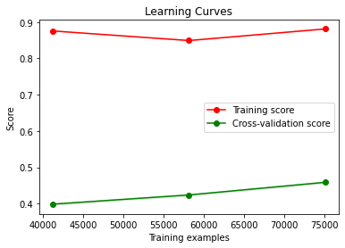

```python
from sklearn.model_selection import learning_curve

# Generate learning curves
train_sizes, train_scores, test_scores = learning_curve(
    pipeline, X_train_smote, y_train_smote, cv=cv, train_sizes=np.linspace(0.1, 1.0, 5), scoring='accuracy')

# Calculate mean and standard deviation for train and test scores
train_mean = np.mean(train_scores, axis=1)
train_std = np.std(train_scores, axis=1)
test_mean = np.mean(test_scores, axis=1)
test_std = np.std(test_scores, axis=1)

# Plot learning curves
plt.fill_between(train_sizes, train_mean - train_std, train_mean + train_std, color='r', alpha=0.1)
plt.fill_between(train_sizes, test_mean - test_std, test_mean + test_std, color='g', alpha=0.1)
plt.plot(train_sizes, train_mean, 'o-', color='r', label="Training score")
plt.plot(train_sizes, test_mean, 'o-', color='g', label="Cross-validation score")

plt.title("Learning Curves")
plt.xlabel("Training examples")
plt.ylabel("Score")
plt.legend(loc="best")
plt.show()
```

The above code was executed in another environment as each execution was taking too long to process. To make sure time was used effciently, I ran the above code in another notebook.

## LSTM Neural Network after SMOTE

```python
from sklearn.preprocessing import StandardScaler

scaler = StandardScaler()
X_train_scaled = scaler.fit_transform(X_train_smote)
X_test_scaled = scaler.transform(X_test)

# Reshape data for neural network input if using Conv1D
X_train_reshaped = X_train_scaled.reshape(X_train_scaled.shape[0], X_train_scaled.shape[1], 1)
X_test_reshaped = X_test_scaled.reshape(X_test_scaled.shape[0], X_test_scaled.shape[1], 1)
```

```python
from sklearn.preprocessing import LabelEncoder

label_encoder = LabelEncoder()
y_train_encoded = label_encoder.fit_transform(y_train_smote)
y_test_encoded = label_encoder.transform(y_test)
```

```python
from tensorflow.keras.models import Sequential
from tensorflow.keras.layers import LSTM, Dense, Dropout

model = Sequential([
    LSTM(50, return_sequences=True, input_shape=(X_train_reshaped.shape[1], 1)),  # LSTM layer with return_sequences=True
    Dropout(0.2),  # Dropout for regularization
    LSTM(50),  # Second LSTM layer
    Dropout(0.2),  # Another dropout layer
    Dense(50, activation='relu'),  # A dense layer
    Dense(len(np.unique(y_train_encoded)), activation='softmax')  # Output layer
])

model.compile(optimizer='adam', loss='sparse_categorical_crossentropy', metrics=['accuracy'])
```

[output not shown]

```python
history = model.fit(
    X_train_reshaped, y_train_encoded,
    epochs=50,
    batch_size=64,
    validation_data=(X_test_reshaped, y_test_encoded),
    verbose=1
)
```

[output not shown]

## SMOTE balancing before the preprocessing and then checking the report

```python
raw_df = pd.read_csv("dataset (1).csv")
```

```python
X_raw = raw_df.drop('track_genre', axis=1)
y_raw = raw_df['track_genre']

# Splitting the dataset into training and test sets
X_train_raw, X_test_raw, y_train_raw, y_test_raw = train_test_split(X_raw, y_raw, test_size=0.2, random_state=42)

non_predictive_columns = ['track_id', 'album_name', 'track_name', 'artists']
X_train_raw = X_train_raw.drop(non_predictive_columns, axis=1)
X_test_raw = X_test_raw.drop(non_predictive_columns, axis=1)
```

```python
X_train_raw_smote, y_train_raw_smote = smote.fit_resample(X_train_raw, y_train_raw)

# Train the model
model.fit(X_train_raw_smote, y_train_raw_smote)

# Print the classification report on the training data
y_pred_train_raw = model.predict(X_train_raw_smote)
print("Training Data Classification Report:")
print(classification_report(y_train_raw_smote, y_pred_train_raw))

# Fit the model on the testing data
#model.fit(X_test_raw, y_test_raw)

# Print the classification report on the testing data
y_pred_test_raw = model.predict(X_test_raw)
print("Testing Data Classification Report:")
print(classification_report(y_test_raw, y_pred_test_raw))
```

```
Training Data Classification Report:
                   precision    recall  f1-score   support

         acoustic       1.00      1.00      1.00       827
         afrobeat       1.00      1.00      1.00       827
         alt-rock       1.00      1.00      1.00       827
      alternative       1.00      1.00      1.00       827
          ambient       1.00      1.00      1.00       827
            anime       1.00      1.00      1.00       827
      black-metal       1.00      1.00      1.00       827
        bluegrass       1.00      1.00      1.00       827
            blues       1.00      1.00      1.00       827
           brazil       1.00      1.00      1.00       827
        breakbeat       1.00      1.00      1.00       827
          british       1.00      1.00      1.00       827
         cantopop       1.00      1.00      1.00       827
    chicago-house       1.00      1.00      1.00       827
         children       1.00      1.00      1.00       827
            chill       1.00      1.00      1.00       827
        classical       1.00      1.00      1.00       827
             club       1.00      1.00      1.00       827
           comedy       1.00      1.00      1.00       827
          country       1.00      1.00      1.00       827
            dance       1.00      1.00      1.00       827
        dancehall       1.00      1.00      1.00       827
      death-metal       1.00      1.00      1.00       827
       deep-house       1.00      1.00      1.00       827
   detroit-techno       1.00      1.00      1.00       827
            disco       1.00      1.00      1.00       827
           disney       1.00      1.00      1.00       827
    drum-and-bass       1.00      1.00      1.00       827
              dub       1.00      1.00      1.00       827
          dubstep       1.00      1.00      1.00       827
              edm       1.00      1.00      1.00       827
          electro       1.00      1.00      1.00       827
       electronic       1.00      1.00      1.00       827
              emo       1.00      1.00      1.00       827
             folk       1.00      1.00      1.00       827
            forro       1.00      1.00      1.00       827
           french       1.00      1.00      1.00       827
```

[output cut: 188 more lines]

```
             soul       1.00      1.00      1.00       194
          spanish       1.00      1.00      1.00       203
            study       1.00      1.00      1.00       186
          swedish       1.00      1.00      1.00       181
        synth-pop       1.00      1.00      1.00       193
            tango       1.00      1.00      1.00       204
           techno       1.00      1.00      1.00       205
           trance       1.00      1.00      1.00       197
         trip-hop       1.00      1.00      1.00       177
          turkish       1.00      1.00      1.00       183
      world-music       1.00      1.00      1.00       181

         accuracy                           1.00     22800
        macro avg       1.00      1.00      1.00     22800
     weighted avg       1.00      1.00      1.00     22800
```

# Executive Summary: Audio Feature Analysis for Music Genre Classification

The project employs advanced machine learning and deep learning methodologies to tackle the complex challenge of music genre classification using the Spotify Tracks Dataset. This dataset, known for its extensive and multifaceted composition, provides a rich canvas to explore the relationship between various audio features and music genres.

### Key Components of the Notebook:

**Data Preprocessing:** The notebook begins with comprehensive data preprocessing steps. It includes cleaning of non-ASCII characters, normalization of numerical data, and handling missing values to ensure data quality and consistency. This phase is crucial for preparing the dataset for effective model training and analysis.

**Exploratory Data Analysis (EDA):** The EDA section provides a deep dive into the distribution of key audio features such as energy, danceability, and loudness. The analyses reveal insights into the data structure and existing patterns that could influence the genre classification process.

**Model Evaluation and Optimization:** The notebook details the process of model tuning and optimization. Techniques such as cross-validation and hyperparameter tuning are employed to enhance model accuracy and generalizability. The performance of each model is critically assessed through metrics such as accuracy, precision, recall, and F1-score.